# DS7331_Lab-2_Tenure_Models

Jeremy Otsap, Shawn Jung, Lance Dacy, Amber Burnett

2/29/2020

# SMU Machine Learning 1 DS7331

## Lab 2 Part B - Tenure

**Telco Churn Data Set**  
https://www.kaggle.com/blastchar/telco-customer-churn

- Jeremy Otsap - jotsap@mail.smu.edu
- Shawn Jung - shawnj@mail.smu.edu
- Lance Dacy - ldacy@mail.smu.edu
- Amber Burnett - aburnett@mail.smu.edu

### Business Understanding

We are looking at customer data from a north American Telco provider. The purpose being to retain existing customers. In telecommunications, the estimated cost of new customer acquisition is approximately 5x higher than retaining an existing customer. Furthermore, only a third of customers switch carriers due to lower prices; more and more factors such as dissatisfaction with quality of service, advancing technology and media features, competitors having better cellular coverage, and poorly implemented loyalty programs are all contributing to customer attrition.

From our prior Churn models we see that one of the most significant predictors **Tenure**

### Data Understanding

**Data Dictionary**  
We are provided a CSV set of 21 features and 7043 anonymyzed customers.

- **customerID**: Unique alpha-numeric string to anonymously represent an individual customer
- **gender**: Categorical String value to represent customer’s gender (Male or Female)
- **SeniorCitizen**: Boolean int value to show whether the customer is a senior citizen or not (1, 0)
- **Partner**: Boolean string value showing whether the customer has a partner or not (Yes, No)
- **Dependents**: Boolean string value showing whether the customer has dependents or not (Yes, No)
- **tenure**: Numeric value showing number of months the customer has stayed with the company
- **PhoneService**: Boolean string value showing whether the customer has a phone service or not (Yes, No)
- **MultipleLines**: Categorical string value that shows if the customer has multiple lines or not (Yes, No, No phone service)
- **InternetService**: Categorical string value that shows the customer’s internet service provider (DSL, Fiber optic, No)
- **OnlineSecurity**: Categorical string value showing whether the customer has online security or not (Yes, No, No internet service)
- **OnlineBackup**: Categorical string showing whether the customer has online backup or not (Yes, No, No internet service)
- **DeviceProtection**: Categorical string showing whether the customer has device protection or not (Yes, No, No internet service)
- **TechSupport**: Categorical string showing whether the customer has tech support or not (Yes, No, No internet service)
- **StreamingTV**: Categorical string showing whether the customer has streaming TV or not (Yes, No, No internet service)
- **StreamingMovies**: Categorical string showing whether the customer has streaming movies or not (Yes, No, No internet service)
- **Contract**: Categorical string that represents the contract term (Month-to-month, One year, Two year)
- **PaperlessBilling**: Boolean string showing whether the customer has paperless billing or not (Yes, No)
- **PaymentMethod**: Categorical string that shows the customer’s payment method (Electronic check, Mailed check, Bank transfer (automatic), Credit card (automatic))
- **MonthlyCharges**: Numeric value showing the amount charged to the customer each month
- **TotalCharges**: Numeric value showing the total amount charged to the customer
- **Churn**: Boolean string showing whether or not the customer ‘churned’ or terminated ser vices (Yes or No)

### Initial Data Examination

As we can see most of the predictor variables are categorical, as is the response “Churn.” However there are a few numerical variables as well specifically relating to the customer’s spend, as well as the length of their contract.

```r
# dataframe
tenure.df <- read.csv('https://raw.githubusercontent.com/jotsap/DS7331/master/data/churn.csv')

str(tenure.df)
```

```
## 'data.frame':    7043 obs. of  21 variables:
##  $ customerID      : Factor w/ 7043 levels "0002-ORFBO","0003-MKNFE",..: 5376 3963 2565 5536 6512 6552 1003 4771 5605 4535 ...
##  $ gender          : Factor w/ 2 levels "Female","Male": 1 2 2 2 1 1 2 1 1 2 ...
##  $ SeniorCitizen   : int  0 0 0 0 0 0 0 0 0 0 ...
##  $ Partner         : Factor w/ 2 levels "No","Yes": 2 1 1 1 1 1 1 1 2 1 ...
##  $ Dependents      : Factor w/ 2 levels "No","Yes": 1 1 1 1 1 1 2 1 1 2 ...
##  $ tenure          : int  1 34 2 45 2 8 22 10 28 62 ...
##  $ PhoneService    : Factor w/ 2 levels "No","Yes": 1 2 2 1 2 2 2 1 2 2 ...
##  $ MultipleLines   : Factor w/ 3 levels "No","No phone service",..: 2 1 1 2 1 3 3 2 3 1 ...
##  $ InternetService : Factor w/ 3 levels "DSL","Fiber optic",..: 1 1 1 1 2 2 2 1 2 1 ...
##  $ OnlineSecurity  : Factor w/ 3 levels "No","No internet service",..: 1 3 3 3 1 1 1 3 1 3 ...
##  $ OnlineBackup    : Factor w/ 3 levels "No","No internet service",..: 3 1 3 1 1 1 3 1 1 3 ...
##  $ DeviceProtection: Factor w/ 3 levels "No","No internet service",..: 1 3 1 3 1 3 1 1 3 1 ...
##  $ TechSupport     : Factor w/ 3 levels "No","No internet service",..: 1 1 1 3 1 1 1 1 3 1 ...
##  $ StreamingTV     : Factor w/ 3 levels "No","No internet service",..: 1 1 1 1 1 3 3 1 3 1 ...
##  $ StreamingMovies : Factor w/ 3 levels "No","No internet service",..: 1 1 1 1 1 3 1 1 3 1 ...
##  $ Contract        : Factor w/ 3 levels "Month-to-month",..: 1 2 1 2 1 1 1 1 1 2 ...
##  $ PaperlessBilling: Factor w/ 2 levels "No","Yes": 2 1 2 1 2 2 2 1 2 1 ...
##  $ PaymentMethod   : Factor w/ 4 levels "Bank transfer (automatic)",..: 3 4 4 1 3 3 2 4 3 1 ...
##  $ MonthlyCharges  : num  29.9 57 53.9 42.3 70.7 ...
##  $ TotalCharges    : num  29.9 1889.5 108.2 1840.8 151.7 ...
##  $ Churn           : Factor w/ 2 levels "No","Yes": 1 1 2 1 2 2 1 1 2 1 ...
```

```r
head(tenure.df)
```

```
##   customerID gender SeniorCitizen Partner Dependents tenure PhoneService
## 1 7590-VHVEG Female             0     Yes         No      1           No
## 2 5575-GNVDE   Male             0      No         No     34          Yes
## 3 3668-QPYBK   Male             0      No         No      2          Yes
## 4 7795-CFOCW   Male             0      No         No     45           No
## 5 9237-HQITU Female             0      No         No      2          Yes
## 6 9305-CDSKC Female             0      No         No      8          Yes
##      MultipleLines InternetService OnlineSecurity OnlineBackup
## 1 No phone service             DSL             No          Yes
## 2               No             DSL            Yes           No
## 3               No             DSL            Yes          Yes
## 4 No phone service             DSL            Yes           No
## 5               No     Fiber optic             No           No
## 6              Yes     Fiber optic             No           No
##   DeviceProtection TechSupport StreamingTV StreamingMovies       Contract
```

[output cut: 20 more lines]

CustomerID is simply a placeholder value to represent an anonomyzed customer and is not necessary for analysis. Thus we will remove it. Additionally R can convert a data type to factor, thus we will convert the numerical SeniorCitizen variable to a factor and store it as a separate column

```r
# CustomerID not necessary for analysis
tenure.df %>% dplyr::select(-customerID)  -> tenure.df
# alternate code: tenure.df$customerID <- NULL


# make FACTOR flavor of SeniorCitizen column
# recode 1 as "Yes" and 0 as "No"
dplyr::recode_factor(
  tenure.df$SeniorCitizen,
  `1` = "Yes", `0` = "No"
  ) -> tenure.df$SeniorCitizen
# alternate code: tenure.df <- tenure.df %>% mutate(SeniorCitizen = factor(SeniorCitizen))

glimpse(tenure.df)
```

```
## Observations: 7,043
## Variables: 20
## $ gender           <fct> Female, Male, Male, Male, Female, Female, Mal...
## $ SeniorCitizen    <fct> No, No, No, No, No, No, No, No, No, No, No, N...
## $ Partner          <fct> Yes, No, No, No, No, No, No, No, Yes, No, Yes...
## $ Dependents       <fct> No, No, No, No, No, No, Yes, No, No, Yes, Yes...
## $ tenure           <int> 1, 34, 2, 45, 2, 8, 22, 10, 28, 62, 13, 16, 5...
## $ PhoneService     <fct> No, Yes, Yes, No, Yes, Yes, Yes, No, Yes, Yes...
## $ MultipleLines    <fct> No phone service, No, No, No phone service, N...
## $ InternetService  <fct> DSL, DSL, DSL, DSL, Fiber optic, Fiber optic,...
## $ OnlineSecurity   <fct> No, Yes, Yes, Yes, No, No, No, Yes, No, Yes, ...
## $ OnlineBackup     <fct> Yes, No, Yes, No, No, No, Yes, No, No, Yes, N...
## $ DeviceProtection <fct> No, Yes, No, Yes, No, Yes, No, No, Yes, No, N...
## $ TechSupport      <fct> No, No, No, Yes, No, No, No, No, Yes, No, No,...
## $ StreamingTV      <fct> No, No, No, No, No, Yes, Yes, No, Yes, No, No...
## $ StreamingMovies  <fct> No, No, No, No, No, Yes, No, No, Yes, No, No,...
## $ Contract         <fct> Month-to-month, One year, Month-to-month, One...
## $ PaperlessBilling <fct> Yes, No, Yes, No, Yes, Yes, Yes, No, Yes, No,...
## $ PaymentMethod    <fct> Electronic check, Mailed check, Mailed check,...
## $ MonthlyCharges   <dbl> 29.85, 56.95, 53.85, 42.30, 70.70, 99.65, 89....
## $ TotalCharges     <dbl> 29.85, 1889.50, 108.15, 1840.75, 151.65, 820....
## $ Churn            <fct> No, No, Yes, No, Yes, Yes, No, No, Yes, No, N...
```

### Secondary Factor: Tenure

**Long-term vs Short-term**

Looking at the length of contract as secondary analysis. We can see that the range of values is from 0 months for brand new customers, up to 72 months

For our initial model, we simply want a binomial model that predicts if this is a “Short-term” or “Long-term” customer, based on if their tenure is **12 months** or more

- Short_Term = 0 - 12 months
- Long_Term = 13+ months

```r
# range of values
range(tenure.df$tenure)
```

```
## [1]  0 72
```

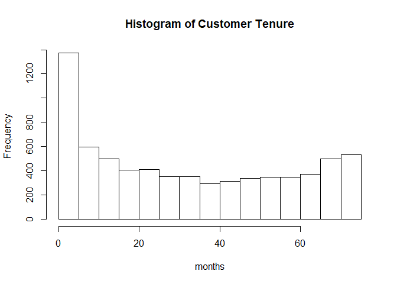

```r
# graphical look
hist(tenure.df$tenure, main = "Histogram of Customer Tenure", xlab = "months")
```

```r
# creating bins for tenure
# Short_Term: 12 months or less
# Old: 13+ months
# NOTE: splits are INCLUSIVE

cut(tenure.df$tenure,
    breaks = c(0,12,999),
    labels = c("Short_Term","Long_Term"),
    include.lowest = T
    ) -> tenure.df$tenureBinary

# validate accuracy new Annual Income categorical parameter
tenure.df[c(1,5,10,15,20,25,30,35,40,45),c("tenure","tenureBinary")]
```

```
##    tenure tenureBinary
## 1       1   Short_Term
## 5       2   Short_Term
## 10     62    Long_Term
## 15     25    Long_Term
## 20     21    Long_Term
## 25     49    Long_Term
## 30     17    Long_Term
## 35      1   Short_Term
## 40     11   Short_Term
## 45     13    Long_Term
```

We can see that **Short_Term** customers that have been enrolled make up around 31% of the total 7000 customers

```r
# plot of tenureBinary
table(tenure.df$tenureBinary)
```

```
##
## Short_Term  Long_Term
##       2186       4857
```

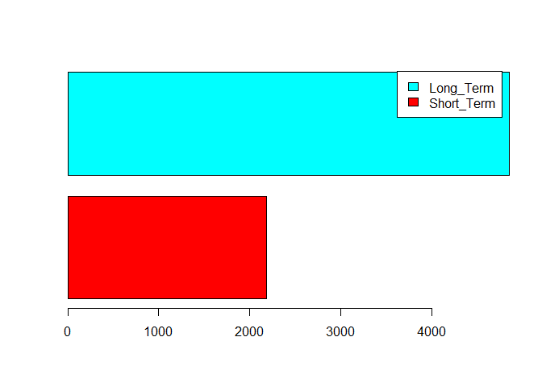

```r
barplot((tenure.df %>% count(tenureBinary))$n,
        horiz = T,
        legend.text = (tenure.df %>% count(tenureBinary))$tenureBinary,
        col = rainbow(2))
```

**Churn = Yes Customers**

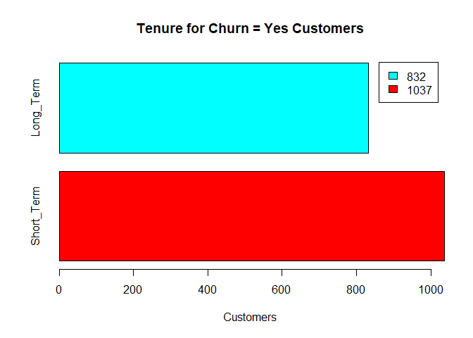

```r
# Plot of New vs Old for Churn = Yes Customers

barplot( tenure.df[tenure.df$Churn == "Yes","tenureBinary"] %>% table(),
        horiz = T,
        legend.text = tenure.df[tenure.df$Churn == "Yes","tenureBinary"] %>% table(),
        col = rainbow(2),
        main = "Tenure for Churn = Yes Customers",
        xlab = "Customers")
```

### Data Leaking

Because we are looking to accurately predict **tenure** we need to prevent data leaking from information we wouldn’t necessarily have. Thus from our *training* data we need to remove the following:

- MonthlyCharges
- TotalCharges
- Churn
- Tenure

```r
# remove data leakage
tenure.df %>% dplyr::select(-c(Churn,MonthlyCharges,TotalCharges,tenure) )  -> tenure_bi.df

glimpse(tenure_bi.df)
```

```
## Observations: 7,043
## Variables: 17
## $ gender           <fct> Female, Male, Male, Male, Female, Female, Mal...
## $ SeniorCitizen    <fct> No, No, No, No, No, No, No, No, No, No, No, N...
## $ Partner          <fct> Yes, No, No, No, No, No, No, No, Yes, No, Yes...
## $ Dependents       <fct> No, No, No, No, No, No, Yes, No, No, Yes, Yes...
## $ PhoneService     <fct> No, Yes, Yes, No, Yes, Yes, Yes, No, Yes, Yes...
## $ MultipleLines    <fct> No phone service, No, No, No phone service, N...
## $ InternetService  <fct> DSL, DSL, DSL, DSL, Fiber optic, Fiber optic,...
## $ OnlineSecurity   <fct> No, Yes, Yes, Yes, No, No, No, Yes, No, Yes, ...
## $ OnlineBackup     <fct> Yes, No, Yes, No, No, No, Yes, No, No, Yes, N...
## $ DeviceProtection <fct> No, Yes, No, Yes, No, Yes, No, No, Yes, No, N...
## $ TechSupport      <fct> No, No, No, Yes, No, No, No, No, Yes, No, No,...
## $ StreamingTV      <fct> No, No, No, No, No, Yes, Yes, No, Yes, No, No...
## $ StreamingMovies  <fct> No, No, No, No, No, Yes, No, No, Yes, No, No,...
## $ Contract         <fct> Month-to-month, One year, Month-to-month, One...
## $ PaperlessBilling <fct> Yes, No, Yes, No, Yes, Yes, Yes, No, Yes, No,...
## $ PaymentMethod    <fct> Electronic check, Mailed check, Mailed check,...
## $ tenureBinary     <fct> Short_Term, Long_Term, Short_Term, Long_Term,...
```

**ADDITIONAL BUSINESS VALUE**

From a business point, while we know if they sign up for a 1 or 2 year contract certainly increases the likelihood of staying 12+ months, there isn’t a lot of business value there. What we want is to determine what services or bundles can be offered to increase customer loyalty and longevity. I.e. the real value to upsell and/or retain customers is to have a better understanding of who wants what services, right? Do unmarried females with 1+ dependents care about online backup for their photos?

Therefore we need to remove this as well

```r
# remove data leakage
tenure_bi.df %>% dplyr::select(-Contract ) -> tenure_bi.df

glimpse(tenure_bi.df)
```

```
## Observations: 7,043
## Variables: 16
## $ gender           <fct> Female, Male, Male, Male, Female, Female, Mal...
## $ SeniorCitizen    <fct> No, No, No, No, No, No, No, No, No, No, No, N...
## $ Partner          <fct> Yes, No, No, No, No, No, No, No, Yes, No, Yes...
## $ Dependents       <fct> No, No, No, No, No, No, Yes, No, No, Yes, Yes...
## $ PhoneService     <fct> No, Yes, Yes, No, Yes, Yes, Yes, No, Yes, Yes...
## $ MultipleLines    <fct> No phone service, No, No, No phone service, N...
## $ InternetService  <fct> DSL, DSL, DSL, DSL, Fiber optic, Fiber optic,...
## $ OnlineSecurity   <fct> No, Yes, Yes, Yes, No, No, No, Yes, No, Yes, ...
## $ OnlineBackup     <fct> Yes, No, Yes, No, No, No, Yes, No, No, Yes, N...
## $ DeviceProtection <fct> No, Yes, No, Yes, No, Yes, No, No, Yes, No, N...
## $ TechSupport      <fct> No, No, No, Yes, No, No, No, No, Yes, No, No,...
## $ StreamingTV      <fct> No, No, No, No, No, Yes, Yes, No, Yes, No, No...
## $ StreamingMovies  <fct> No, No, No, No, No, Yes, No, No, Yes, No, No,...
## $ PaperlessBilling <fct> Yes, No, Yes, No, Yes, Yes, Yes, No, Yes, No,...
## $ PaymentMethod    <fct> Electronic check, Mailed check, Mailed check,...
## $ tenureBinary     <fct> Short_Term, Long_Term, Short_Term, Long_Term,...
```

### Missing Values

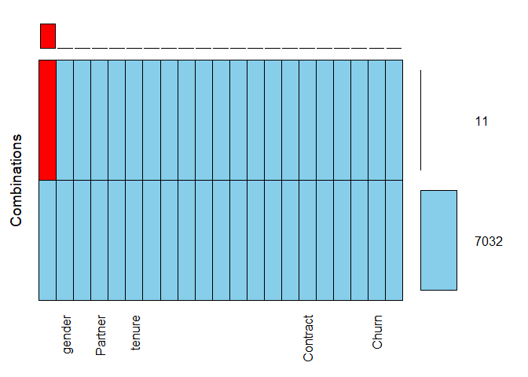

```
##
##  Variables sorted by number of missings:
##          Variable Count
##      TotalCharges    11
##            gender     0
##     SeniorCitizen     0
##           Partner     0
##        Dependents     0
##            tenure     0
##      PhoneService     0
##     MultipleLines     0
##   InternetService     0
##    OnlineSecurity     0
##      OnlineBackup     0
##  DeviceProtection     0
##       TechSupport     0
##       StreamingTV     0
##   StreamingMovies     0
##          Contract     0
##  PaperlessBilling     0
##     PaymentMethod     0
##    MonthlyCharges     0
##             Churn     0
##      tenureBinary     0
```

```r
# from VIM package
aggr(tenure.df,
     prop = FALSE,
     combined = TRUE,
     numbers = TRUE,
     sortVars = TRUE,
     sortCombs = TRUE)
```

# MODELING TENURE

## Binomial Logistic Regression: Full Model

First we need to split the data into a train and test set, with 80% of the data going into the train set. Note that createDataPartition() automatically accounts for the unbalanced levels of y [in this case ‘tenure’] in an attempt to balance the class distributions within the splits

```r
# creating the 80 data partition
tenure_bi_split <- createDataPartition(tenure_bi.df$tenureBinary, p = 0.8, list = F)
# including 80 for training set
tenure_bi_train.df <- tenure_bi.df[tenure_bi_split,]
# excluding 80 for testing set
tenure_bi_test.df <- tenure_bi.df[-tenure_bi_split,]

# validating
head(tenure_bi_test.df)
```

```
##    gender SeniorCitizen Partner Dependents PhoneService    MultipleLines
## 14   Male            No      No         No          Yes              Yes
## 16 Female            No     Yes        Yes          Yes              Yes
## 20 Female            No      No         No          Yes               No
## 24 Female            No     Yes         No          Yes              Yes
## 27   Male            No     Yes        Yes          Yes              Yes
## 28   Male            No     Yes        Yes           No No phone service
##    InternetService OnlineSecurity OnlineBackup DeviceProtection
## 14     Fiber optic             No          Yes              Yes
## 16     Fiber optic            Yes          Yes              Yes
## 20     Fiber optic             No          Yes              Yes
## 24             DSL             No          Yes               No
## 27     Fiber optic             No          Yes               No
## 28             DSL             No          Yes               No
##    TechSupport StreamingTV StreamingMovies PaperlessBilling
## 14          No         Yes             Yes              Yes
## 16         Yes         Yes             Yes               No
## 20          No          No             Yes              Yes
## 24         Yes          No              No              Yes
## 27          No         Yes             Yes              Yes
## 28          No          No              No               No
##                PaymentMethod tenureBinary
## 14 Bank transfer (automatic)    Long_Term
## 16   Credit card (automatic)    Long_Term
## 20          Electronic check    Long_Term
## 24   Credit card (automatic)    Long_Term
## 27          Electronic check    Long_Term
## 28          Electronic check   Short_Term
```

```r
head(tenure_bi_train.df)
```

```
##   gender SeniorCitizen Partner Dependents PhoneService    MultipleLines
## 1 Female            No     Yes         No           No No phone service
## 2   Male            No      No         No          Yes               No
## 3   Male            No      No         No          Yes               No
## 4   Male            No      No         No           No No phone service
## 5 Female            No      No         No          Yes               No
## 6 Female            No      No         No          Yes              Yes
##   InternetService OnlineSecurity OnlineBackup DeviceProtection TechSupport
## 1             DSL             No          Yes               No          No
## 2             DSL            Yes           No              Yes          No
## 3             DSL            Yes          Yes               No          No
## 4             DSL            Yes           No              Yes         Yes
## 5     Fiber optic             No           No               No          No
## 6     Fiber optic             No           No              Yes          No
##   StreamingTV StreamingMovies PaperlessBilling             PaymentMethod
## 1          No              No              Yes          Electronic check
## 2          No              No               No              Mailed check
## 3          No              No              Yes              Mailed check
## 4          No              No               No Bank transfer (automatic)
## 5          No              No              Yes          Electronic check
## 6         Yes             Yes              Yes          Electronic check
##   tenureBinary
## 1   Short_Term
## 2    Long_Term
## 3   Short_Term
## 4    Long_Term
## 5   Short_Term
## 6   Short_Term
```

Note that R automatically processes the 1-bit encoding on factor variables. However our model has some issues due to the fact that there is a high amount of correlation. For example if a customer has no Internet service, they will always have no for ancillary services like Online Security or Online Backup.

Our model here sees almost every parameter as *significant* to the model looking at the p-values for the following

```r
# create logistic regression model on train data
# R will automatically create dummy variables on factors
tenure_bi_train.logit <- glm(tenureBinary ~ .,
                          data = tenure_bi_train.df,
                          family = binomial(link = "logit") )

summary(tenure_bi_train.logit)
```

```
##
## Call:
## glm(formula = tenureBinary ~ ., family = binomial(link = "logit"),
##     data = tenure_bi_train.df)
##
## Deviance Residuals:
##     Min       1Q   Median       3Q      Max
## -3.0271  -0.7689   0.3276   0.7126   2.1368
##
## Coefficients: (7 not defined because of singularities)
##                                       Estimate Std. Error z value Pr(>|z|)
## (Intercept)                          -0.380180   0.187216  -2.031   0.0423
## genderMale                            0.090810   0.070063   1.296   0.1949
## SeniorCitizenNo                      -0.278909   0.104996  -2.656   0.0079
## PartnerYes                            0.984563   0.083330  11.815  < 2e-16
## DependentsYes                         0.055223   0.094098   0.587   0.5573
## PhoneServiceYes                      -0.291187   0.138751  -2.099   0.0358
## MultipleLinesNo phone service               NA         NA      NA       NA
## MultipleLinesYes                      1.034383   0.084488  12.243  < 2e-16
## InternetServiceFiber optic            0.037475   0.106658   0.351   0.7253
## InternetServiceNo                     1.657025   0.124128  13.349  < 2e-16
## OnlineSecurityNo internet service           NA         NA      NA       NA
## OnlineSecurityYes                     1.111214   0.101993  10.895  < 2e-16
## OnlineBackupNo internet service             NA         NA      NA       NA
## OnlineBackupYes                       0.974343   0.091313  10.670  < 2e-16
## DeviceProtectionNo internet service         NA         NA      NA       NA
## DeviceProtectionYes                   0.817451   0.094504   8.650  < 2e-16
## TechSupportNo internet service              NA         NA      NA       NA
## TechSupportYes                        0.776421   0.101298   7.665 1.79e-14
## StreamingTVNo internet service              NA         NA      NA       NA
## StreamingTVYes                        0.518415   0.095052   5.454 4.92e-08
## StreamingMoviesNo internet service          NA         NA      NA       NA
## StreamingMoviesYes                    0.407528   0.094595   4.308 1.65e-05
## PaperlessBillingYes                  -0.058042   0.078344  -0.741   0.4588
## PaymentMethodCredit card (automatic) -0.007087   0.127653  -0.056   0.9557
## PaymentMethodElectronic check        -1.070941   0.110211  -9.717  < 2e-16
## PaymentMethodMailed check            -1.204447   0.112495 -10.707  < 2e-16
##
## (Intercept)                          *
## genderMale
```

[output cut: 19 more lines]

```
## StreamingMoviesYes                   ***
## PaperlessBillingYes
## PaymentMethodCredit card (automatic)
## PaymentMethodElectronic check        ***
## PaymentMethodMailed check            ***
## ---
## Signif. codes:  0 '***' 0.001 '**' 0.01 '*' 0.05 '.' 0.1 ' ' 1
##
## (Dispersion parameter for binomial family taken to be 1)
##
##     Null deviance: 6980.7  on 5634  degrees of freedom
## Residual deviance: 4994.5  on 5616  degrees of freedom
## AIC: 5032.5
##
## Number of Fisher Scoring iterations: 5
```

### Visualize the coefficients of the Full Logistic Model

Visualizing the coefficients, we can see the most *influential* factors are:

- Customers having no Internet service with a strong positive coefficient
- PaymentMethod of check [both postal or online] with a strong negative coefficient
- Customers with having multiple lines with a strong positive coefficient

Additionally customers having OnlineSecurity, OnlineBackup, and DeviceProtection also had moderately-strong postive coefficients, as well as those who engaged Tech Support and those that lived with a partner.

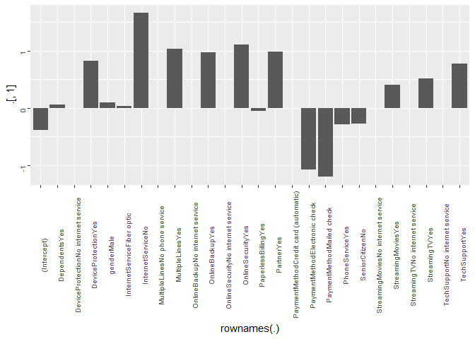

```r
# visualize coefficients
as.data.frame(tenure_bi_train.logit$coefficients) %>% ggplot(aes(y = .[,1], x = rownames(.)) ) + geom_col() + theme( axis.text = element_text(angle = 90, size = rel(0.7)) )
```

###Categorical Parameter Dependence / Correlation

With numerical continuous predictors, it is a fairly simple exercise to test for correlation. With categorical variables it can be somewhat of a challenge, however we do have techniques to demonstrate a relationship between 2 categorical variables by examining their co-dependency

Using Chi-Squared we can get a sense of whether or not the dependency between categorical predictors is significant. And by adding a visual element we can have an estimate of the strength of the dependency

**InternetService and PaymentMethod**

First we look at a dependency between the two most weighted parameters: InternetService and PaymentMethod. We can see there is a dependency between the two.

Because the p-value is so small we can reject H0 and conclude, that the variables, InternetService and PaymentMethod are dependent to each other.

Looking at the various plots below, it seems the following visual relationships exist:

- Fiber customers and paying by e-check
- Customers with no internet prefer paying by mailed check

```r
# Chi-Sq between InternetService and PaymentMethod
chisq.test(
  tenure.df$InternetService, tenure.df$PaymentMethod,
  correct=F)
```

```
##
##  Pearson's Chi-squared test
##
## data:  tenure.df$InternetService and tenure.df$PaymentMethod
## X-squared = 1381.1, df = 6, p-value < 2.2e-16
```

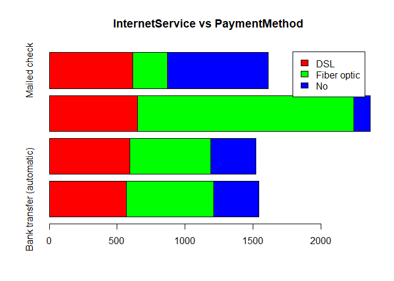

```r
# visualize InternetService and PaymentMethod
barplot(
  table(tenure.df$InternetService, tenure.df$PaymentMethod),
  main = "InternetService vs PaymentMethod",
  legend.text = levels(tenure.df$InternetService),
  col = rainbow(3),
  horiz = T
)
```

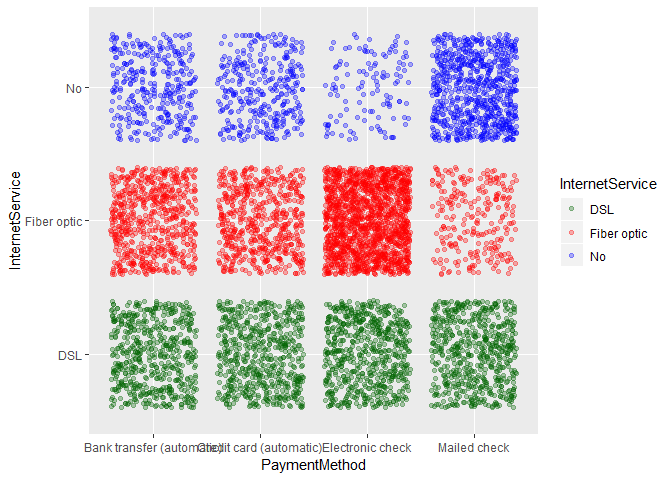

```r
# alternative GGPLOT
ggplot(data = tenure.df, aes(x=PaymentMethod, y=InternetService, color=InternetService)) + geom_jitter(alpha=0.3) + scale_color_manual(breaks = c('DSL','Fiber optic','No'),values=c('darkgreen','red','blue'))
```

**SeniorCitizen vs InternetService**

Suprisingly there are *proportionately* more non-seniors without InternetService. Again the Chi-squared test’s p-value is very low, thus we reject H0 on independence

Possibly an opportunity for a marketing campaign on a younger crowd.

NOTE: more info needed. Are these working middle class families or young college kids?

```r
# Chi-Sq between InternetService and SeniorCitizen
chisq.test(
  tenure.df$InternetService, tenure.df$SeniorCitizen,
  correct=F)
```

```
##
##  Pearson's Chi-squared test
##
## data:  tenure.df$InternetService and tenure.df$SeniorCitizen
## X-squared = 495.8, df = 2, p-value < 2.2e-16
```

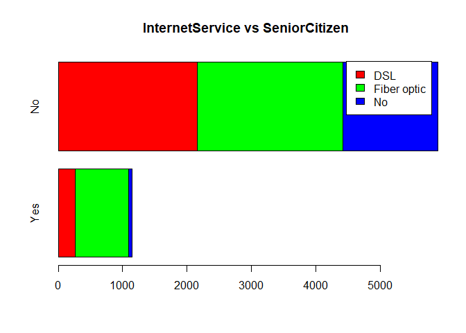

```r
# visualize InternetService and SeniorCitizen
barplot(
  table(tenure.df$InternetService, tenure.df$SeniorCitizen),
  main = "InternetService vs SeniorCitizen",
  horiz = T,
  legend.text = levels(tenure.df$InternetService),
  col = rainbow(3)
)
```

**Dependents vs OnlineBackup**

Again the Chi-squared test’s p-value is very low, thus we reject H0 on independence. Those customers without dependents visually appear to have less adoption of OnlineBackup.

Its likely that those with children will want to backup their baby photos

```r
# Chi-Sq between OnlineBackup and Dependents
chisq.test(
  tenure.df$Dependents, tenure.df$OnlineBackup,
  correct=F)
```

```
##
##  Pearson's Chi-squared test
##
## data:  tenure.df$Dependents and tenure.df$OnlineBackup
## X-squared = 186.58, df = 2, p-value < 2.2e-16
```

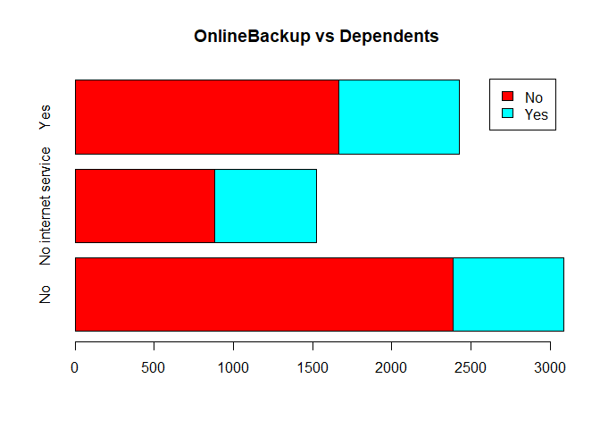

```r
# visualize OnlineBackup and Dependents
barplot(
  table(tenure.df$Dependents, tenure.df$OnlineBackup),
  main = "OnlineBackup vs Dependents",
  legend.text = levels(tenure.df$Dependents),
  col = rainbow(2),
  horiz = T
)
```

**StreamingTV vs StreamingMovies**

This might be an opportunity to cross-market. I.e. “if you like Game of Thrones you’ll love Lord of the Rings”

```r
# Chi-Sq between StreamingTV vs StreamingMovies
chisq.test(
  tenure.df$StreamingMovies, tenure.df$StreamingTV,
  correct=F)
```

```
##
##  Pearson's Chi-squared test
##
## data:  tenure.df$StreamingMovies and tenure.df$StreamingTV
## X-squared = 8374.2, df = 4, p-value < 2.2e-16
```

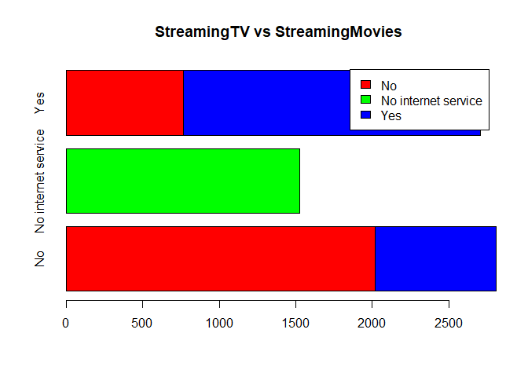

```r
# visualize StreamingTV vs StreamingMovies
barplot(
  table(tenure.df$StreamingMovies, tenure.df$StreamingTV),
  main = "StreamingTV vs StreamingMovies",
  legend.text = levels(tenure.df$StreamingMovies),
  col = rainbow(3),
  horiz = T
)
```

**PhoneService vs DeviceProtection**

Again the Chi-squared test’s p-value is very low. Looks like a large portion of people who do have phone service who have no device protection, regardless of internet.

NOTE: Device Protection typically includes more than just software, but also hardware failures and defects, accidents, etc. Even flip phones and smart phones could be candidates

```r
# Chi-Sq between PhoneService vs DeviceProtection
chisq.test(
  tenure.df$PhoneService, tenure.df$DeviceProtection,
  correct=F)
```

```
##
##  Pearson's Chi-squared test
##
## data:  tenure.df$PhoneService and tenure.df$DeviceProtection
## X-squared = 209.13, df = 2, p-value < 2.2e-16
```

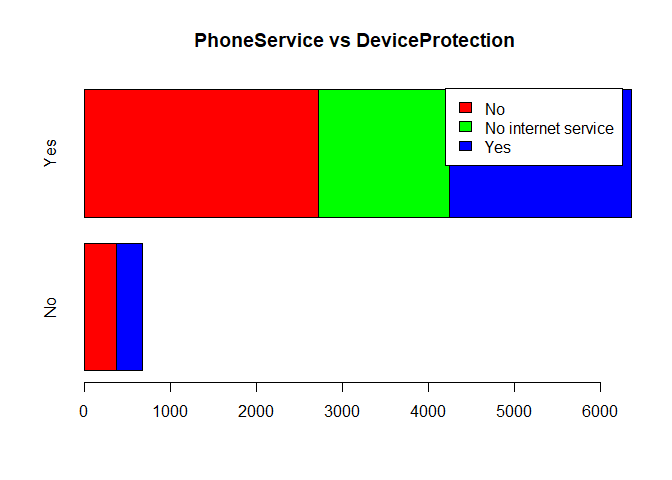

```r
# visualize PhoneService vs DeviceProtection
barplot(
  table(tenure.df$DeviceProtection, tenure.df$PhoneService),
  main = "PhoneService vs DeviceProtection",
  legend.text = levels(tenure.df$DeviceProtection),
  col = rainbow(3),
  horiz = T
)
```

**Dependents vs DeviceProtection**

Again the Chi-squared test’s p-value is very low. Typically dependents are minors, and thus an opportunity to sell device protection to help reduce costs in the event of cracked screens, phones dropped in the bathroom, etc

```r
# Chi-Sq between Dependents vs DeviceProtection
chisq.test(
  tenure.df$Dependents, tenure.df$DeviceProtection,
  correct=F)
```

```
##
##  Pearson's Chi-squared test
##
## data:  tenure.df$Dependents and tenure.df$DeviceProtection
## X-squared = 174.87, df = 2, p-value < 2.2e-16
```

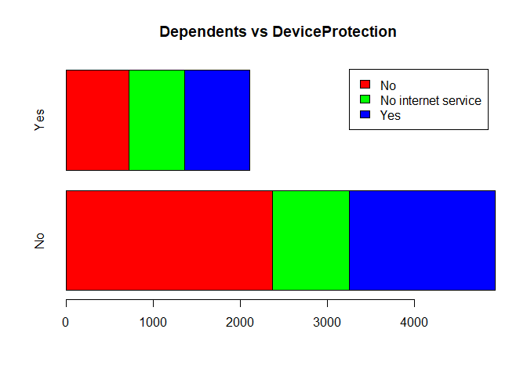

```r
# visualize Dependents vs DeviceProtection
barplot(
  table(tenure.df$DeviceProtection, tenure.df$Dependents),
  main = "Dependents vs DeviceProtection",
  legend.text = levels(tenure.df$DeviceProtection),
  col = rainbow(3),
  horiz = T
)
```

### ROC Curve for Full Binomial Logistic Model

```r
# create predictions
predict(
  tenure_bi_train.logit,
  newdata = tenure_bi_test.df,
  type = "response"
  ) -> tenure_bi_test.pred
```

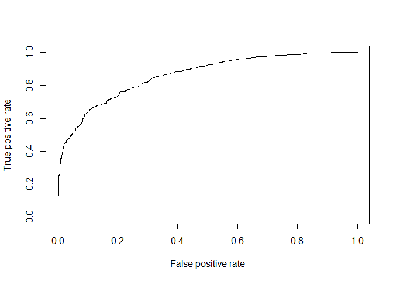

```r
#prediction(tenure_bi_test.pred, tenure_bi_test.df$tenureBinary, label.ordering = c("Short_Term", "Long_Term") )

performance(
  prediction(tenure_bi_test.pred,
             tenure_bi_test.df$tenureBinary,
             label.ordering = c("Short_Term", "Long_Term") ),
  measure = "tpr",
  x.measure = "fpr"
) -> tenure_bi_logit.perf

plot(tenure_bi_logit.perf)
```

```r
# AUC value
print("AUC Value for this model is ")
```

```
## [1] "AUC Value for this model is "
```

```r
performance(
  prediction(tenure_bi_test.pred,
             tenure_bi_test.df$tenureBinary,
             label.ordering = c("Short_Term", "Long_Term")),
  measure = "auc"
)@y.values[[1]]
```

```
## [1] 0.8629936
```

```r
# split into "Long_Term" and "Short_Term" based on 0.5 threadshold
as.numeric(tenure_bi_test.pred > 0.5 ) -> tenure_bi_test.pred

dplyr::recode_factor(
  tenure_bi_test.pred,
  `1` = "Long_Term", `0` = "Short_Term"
  ) -> tenure_bi_test.pred


mean(tenure_bi_test.pred == tenure_bi_test.df$tenureBinary )
```

```
## [1] 0.7947443
```

### Confusion Matrix: Full Binomial Logistic Model

Lets setup a confusion matrix to also see the sensitivity and specificity of the model.

```r
# referencing "old" customers since we want to accurately predict who our long term customers will be

caret::confusionMatrix(
  data = relevel(tenure_bi_test.pred, ref = "Long_Term"),
  reference = relevel(tenure_bi_test.df$tenureBinary, ref = "Long_Term")
)
```

```
## Confusion Matrix and Statistics
##
##             Reference
## Prediction   Long_Term Short_Term
##   Long_Term        860        178
##   Short_Term       111        259
##
##                Accuracy : 0.7947
##                  95% CI : (0.7727, 0.8156)
##     No Information Rate : 0.6896
##     P-Value [Acc > NIR] : < 2.2e-16
##
##                   Kappa : 0.4994
##  Mcnemar's Test P-Value : 0.0001035
##
##             Sensitivity : 0.8857
##             Specificity : 0.5927
##          Pos Pred Value : 0.8285
##          Neg Pred Value : 0.7000
##              Prevalence : 0.6896
##          Detection Rate : 0.6108
##    Detection Prevalence : 0.7372
##       Balanced Accuracy : 0.7392
##
##        'Positive' Class : Long_Term
##
```

## Model Challenges: Variable Correlation and Overfitting

As mentioned earlier we have some issues with this model. Due to the fact that we are predominantly dealing with categorical predictors, it’s not as obvious to identify potential correlation between them; as compared to continuous variables that allow us to simply calculate the Variance Inflation Factor [VIF].

I.e., any customer with “no” for the InternetService predictor is also going to have “no” for ancillary services like OnlineSecurity and OnlineBackup, as well as StreamingTV or StreamingMovies.

The **alias()** command [output omitted due to size] validates this.

For this there are a variety of techniques to simplify the model, leaving only the most influential predictors. We will explore these further

- Feature Selection
- Regularized or Shrinkage

## Feature Selection: Stepwise Regression

Now let’s employ **Feature Selection**, where R iteratively goes through the model adding / removing a predictors based on the calculated significance to the model’s overall performance. There are different metrics which can be used to evaluate this performance; here we find optimal coefficients by using the respective AIC score.

### AIC-Based Stepwise Model

Again almost every predictor is found to have a statistically significant p-value

```r
stepAIC(
  tenure_bi_train.logit,
  trace = F,
  direction = "both"
) -> tenure_bi_step.logit


# view results
summary(tenure_bi_step.logit)
```

```
##
## Call:
## glm(formula = tenureBinary ~ SeniorCitizen + Partner + MultipleLines +
##     OnlineSecurity + OnlineBackup + DeviceProtection + TechSupport +
##     StreamingTV + StreamingMovies + PaymentMethod, family = binomial(link = "logit"),
##     data = tenure_bi_train.df)
##
## Deviance Residuals:
##     Min       1Q   Median       3Q      Max
## -3.0224  -0.7710   0.3266   0.7102   2.1099
##
## Coefficients: (5 not defined because of singularities)
##                                       Estimate Std. Error z value Pr(>|z|)
## (Intercept)                          -0.645354   0.145698  -4.429 9.45e-06
## SeniorCitizenNo                      -0.266812   0.102793  -2.596  0.00944
## PartnerYes                            1.008824   0.073115  13.798  < 2e-16
## MultipleLinesNo phone service         0.275916   0.126084   2.188  0.02864
## MultipleLinesYes                      1.034310   0.082964  12.467  < 2e-16
## OnlineSecurityNo internet service     1.659648   0.108739  15.263  < 2e-16
## OnlineSecurityYes                     1.109595   0.100258  11.067  < 2e-16
## OnlineBackupNo internet service             NA         NA      NA       NA
## OnlineBackupYes                       0.969509   0.091142  10.637  < 2e-16
## DeviceProtectionNo internet service         NA         NA      NA       NA
## DeviceProtectionYes                   0.820657   0.094446   8.689  < 2e-16
## TechSupportNo internet service              NA         NA      NA       NA
## TechSupportYes                        0.773920   0.100100   7.731 1.06e-14
## StreamingTVNo internet service              NA         NA      NA       NA
## StreamingTVYes                        0.519691   0.094269   5.513 3.53e-08
## StreamingMoviesNo internet service          NA         NA      NA       NA
## StreamingMoviesYes                    0.404388   0.093984   4.303 1.69e-05
## PaymentMethodCredit card (automatic) -0.008848   0.127619  -0.069  0.94473
## PaymentMethodElectronic check        -1.073062   0.109598  -9.791  < 2e-16
## PaymentMethodMailed check            -1.199394   0.112133 -10.696  < 2e-16
##
## (Intercept)                          ***
## SeniorCitizenNo                      **
## PartnerYes                           ***
## MultipleLinesNo phone service        *
## MultipleLinesYes                     ***
## OnlineSecurityNo internet service    ***
```

[output cut: 9 more lines]

```
## StreamingMoviesNo internet service
## StreamingMoviesYes                   ***
## PaymentMethodCredit card (automatic)
## PaymentMethodElectronic check        ***
## PaymentMethodMailed check            ***
## ---
## Signif. codes:  0 '***' 0.001 '**' 0.01 '*' 0.05 '.' 0.1 ' ' 1
##
## (Dispersion parameter for binomial family taken to be 1)
##
##     Null deviance: 6980.7  on 5634  degrees of freedom
## Residual deviance: 4997.1  on 5620  degrees of freedom
## AIC: 5027.1
##
## Number of Fisher Scoring iterations: 5
```

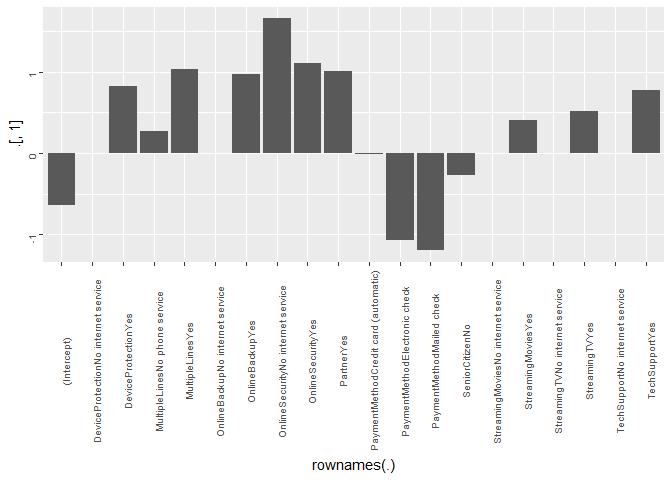

```r
# visualize coefficients
as.data.frame(tenure_bi_step.logit$coefficients) %>% ggplot(aes(y = .[,1], x = rownames(.)) ) + geom_col() + theme( axis.text = element_text(angle = 90, size = rel(0.7)) )
```